# Python Basics

## Hello World

```python
print "Hello World"
```

```
Hello World
```

```python
# python is case sensitive
a = 5
A = 10
# both a and A are different
print "a: ", a, "and A: ", A
```

```
a:  5 and A:  10
```

## Number Operations

```python
a  = 5
b = 10
print "a+b: ", a+b
print "a-b: ", a-b
print "a*b: " , a*b
print "a/b: ",a/b # why 0 not 0.5
print "a%b: ", a%b
print "a/b: ", a/float(b) # or
b = 10.0
print "a/b: ", a/b
print "a^2: ", a**2
```

```
a+b:  15
a-b:  -5
a*b:  50
a/b:  0
a%b:  5
a/b:  0.5
a/b:  0.5
a^2:  25
```

## Lists

```python
test = [] # initiate empty list, not necessary
test = [a,b,"abc"]
print test
test = [1,2,3.0,"abc",1/2.0]
print test
# add new item to existing list
c = 14
test.append(c)
print test
# remove item from list
test.remove("abc")
print test
# extend list
test2 = [10,20,30]
test.extend(test2)
print test
# pop
test.pop(2) # remove and return item from index
print test
# length of list
print "Length of List: ", len(test)
# Count items
print "Count number of 30's: ", test.count(30)
# Index of item
print "index of 30: ",  test.index(30) # in python index start from 0 not 1 so first item is always at position 0 not 1
# print a list item by index
print "item at position 6: ", test[6]
# multiply a list -
print test*2
# List subsetting
print test[:5] # Print list elements from start to 5 th position
print test[3:6] # 3rd to 6th element
print test[-1] # use -1 to get last element
print test[-4:] # you can subset from back
```

```
[10, 1, 'abc']
[1, 2, 3.0, 'abc', 0.5]
[1, 2, 3.0, 'abc', 0.5, 14]
[1, 2, 3.0, 0.5, 14]
[1, 2, 3.0, 0.5, 14, 10, 20, 30]
[1, 2, 0.5, 14, 10, 20, 30]
Length of List:  7
Count number of 30's:  1
index of 30:  6
item at position 6:  30
[1, 2, 0.5, 14, 10, 20, 30, 1, 2, 0.5, 14, 10, 20, 30]
[1, 2, 0.5, 14, 10]
[14, 10, 20]
30
[14, 10, 20, 30]
```

## Strings

```python
# lets creat a string
s = "abc" # s is an string
print s
# or something else
s = s + "def"*3
print s
# convert a number to string
str_a = str(a)
print str_a
print str_a*3 # maths operations on string are different
# lets try to add a number to string
#print str_a +5 # this will give you error
# convert string to list by each caracter
list(s)
# string operations
print s.capitalize()
print s.upper()
print s.lower()
print s.count('def')
print s.count("df")
print s.find("f")
print s.replace("def","xyz") # to replace s = s.replace("def","xyz)
print s.split("d") # return a list with strings separated by "d"
```

```
abc
abcdefdefdef
5
555
Abcdefdefdef
ABCDEFDEFDEF
abcdefdefdef
3
0
5
abcxyzxyzxyz
['abc', 'ef', 'ef', 'ef']
```

## If ....Else

Python is indentation specific language. Note the indentation below in if..else and for loops. if indentations are not proper it results in indentation error.

```python
a = 10; b = 1
if a == b:
    print "a is equal to b"
elif a>b :
    print "a is greater than b"
elif a<b:
    print "a is less than b"
else:
    print "what can i say!"

# chack what happens when two conditions are met from the given try it!

# shorthand
if a==b: print "equal"
num = 20 if a==b else "bad"
print num
```

```
a is greater than b
bad
```

## For Loop

Notice Indents

```python
# Remeber our list test
for i in test:
    print "test has: ", i

# short hand
test_2 = [i/2. for i in test] # double every element of list
print test_2

# misxing for loop and if else ....
for j in test_2:
    if j >1:
        test_2[test_2.index(j)]= 100
    else:
        test_2[test_2.index(j)]=99

print test_2
# or

[100 if test_2[test_2.index(j)]==99 else 99 for j in test_2 ]
```

```
test has:  1
test has:  2
test has:  0.5
test has:  14
test has:  10
test has:  20
test has:  30
[0.5, 1.0, 0.25, 7.0, 5.0, 10.0, 15.0]
[99, 99, 99, 100, 100, 100, 100]
```

```
[100, 100, 100, 99, 99, 99, 99]
```

## Defining Functions

Notice Indents

```python
def first():
   # No argument passed
    print "Hello First!"

first()

def second(to_print):
    print to_print

second("I am second")

def ops(a,b):
    print "a+b: ", a+b
    print "a-b: ", a-b
    print "a*b: " , a*b
    print "a/b: ",a/b # why 0 not 0.5
    print "a%b: ", a%b
    print "a/b: ", a/float(b) # or
    b = 10.0
    print "a/b: ", a/b
    print "a^2: ", a**2

ops(2,100)
```

```
Hello First!
I am second
a+b:  102
a-b:  -98
a*b:  200
a/b:  0
a%b:  2
a/b:  0.02
a/b:  0.2
a^2:  4
```

## File Operations

```python
pnp = open("pride_prejudice.txt")
print pnp.readline()
# print pnp.readlines(3)

# for line in pnp:
#     print line
pnp.close() # closing a file is mandatory

# to bypass need explicit closing of file
with open("pride_prejudice.txt") as text:
    data = text.read()
# automatically closes the file after with statement
#print data
#print words from file
for word in data.split(" ")[:100]:
    print word

## Write to file
with open("myFile.txt",'w') as f:
    f.write("my name is vaibhav.")
```

```
 The Project Gutenberg EBook of Pride and Prejudice, by Jane Austen

The
Project
Gutenberg
EBook
of
Pride
and
Prejudice,
by
Jane
Austen

This
eBook
is
for
the
use
of
anyone
anywhere
at
no
cost
and
with
almost
no
restrictions
whatsoever.

You
may
copy
it,
give
it
away
```

[output cut: 87 more lines]

```


Chapter
1


It
is
a
truth
universally
acknowledged,
that
a
single
```

## Assignment : 1

Read the file pride_prejudice.txt into a variable.

1. Create a list of all the unique words from the file.
2. Print number of unique words in the file.
3. Create a list of lists with count of each word in the whole file. For example [['a',10000], ['the', 23000], ['truth',1000] ....... ]
4. Make sure you lower every word before finding unique and counting. For python "The" is different word than "the". Be careful.

## Libraries

The above operations and functions are basic functionalities of python. They come in basic python. But for special operations we need to import libraries. For example for dataframe operations we have to import **pandas** library. For many machine learning algorithms we have to import **sklearn** library (Official Name: scikit-learn).

We will work on pandas today.

pandas library is a famous and very handy library to handle Dataframe operations. Dataframe is an structured table of colums and rows. Lets see!

```python
import pandas as pd

# read a csv file
data = pd.read_csv("test_data.csv")
print data
```

```
    year month        sales
0   2014   Jan  2296.159055
1   2014   Feb  2517.850145
2   2014   Mar  2767.250322
3   2014   Apr  2678.434712
4   2014   May  2387.231962
5   2014   Jun  2626.109731
6   2014   Jul  2952.867989
7   2014   Aug  2137.858799
8   2014   Sep  2331.783669
9   2014   Oct  2457.271412
10  2014   Nov  2126.593010
11  2014   Dec  2221.375195
12  2015   Jan  2676.017726
13  2015   Feb  3922.541776
14  2015   Mar  3410.706185
15  2015   Apr  2307.675349
16  2015   May  3704.415026
17  2015   Jun  3727.155949
18  2015   Jul  2350.842217
19  2015   Aug  3100.233043
20  2015   Sep  2326.707937
21  2015   Oct  2936.318156
22  2015   Nov  3084.596089
23  2015   Dec  3838.740613
```

```python
print "***head*** \n",data.head(10)
print "\n***tail*** \n",data.tail(2)
print "\n***data description*** \n",data.describe()
```

```
***head***
   year month        sales
0  2014   Jan  2296.159055
1  2014   Feb  2517.850145
2  2014   Mar  2767.250322
3  2014   Apr  2678.434712
4  2014   May  2387.231962
5  2014   Jun  2626.109731
6  2014   Jul  2952.867989
7  2014   Aug  2137.858799
8  2014   Sep  2331.783669
9  2014   Oct  2457.271412

***tail***
    year month        sales
22  2015   Nov  3084.596089
23  2015   Dec  3838.740613

***data description***
              year        sales
count    24.000000    24.000000
mean   2014.500000  2786.947336
std       0.510754   567.046637
min    2014.000000  2126.593010
25%    2014.000000  2330.514736
50%    2014.500000  2651.063729
75%    2015.000000  3088.505328
max    2015.000000  3922.541776
```

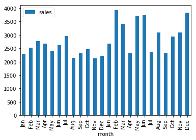

```python
%matplotlib inline
data.plot.bar(x='month',y='sales')
```